# Zambia Trust Index

Institutional

This Community Trust Index assesses the level of trust in the Zambia Red Cross Society by evaluating its competencies and core values. It explores various subdimensions that influence overall trust perceptions. The goal is to pinpoint strengths and identify areas needing enhancement, thereby improving community involvement and aiding in policy formulation. The insights derived from this index are intended to cultivate a more unified and trustworthy atmosphere, supporting Zambia’s sustainable growth and the overall welfare of its communities.

# Sampling

The sampling employed a purposive sampling approach, focusing on the surrounding areas of 20 pre-selected health facilities where the Zambian Red Cross (ZRCS) has an operational presence. This approach was implemented in two provinces, specifically the Eastern and Southern provinces, with two districts selected within each province. The sample was stratified based on health centers.

*See metrics: Metrics*

## Geographic

The two provinces included in the study represent less than 25% of the overall population, and the four districts represent less than 5% of the total population of Zambia.

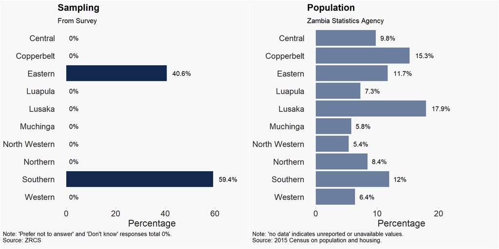

## Coverage

[interactive chart not shown]

## Gender and Age

In terms of age and gender, the overall sample shows minor deviations from the actual population. There is a slight over-representation of females, while younger individuals are slightly under-represented.

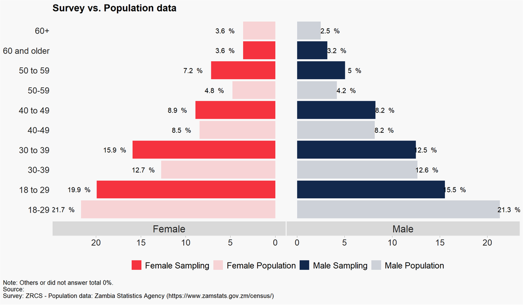

## Education

Although we have encountered challenges in accessing reliable education data, a preliminary analysis suggests that the available education data aligns with expected values for different levels of education. Specifically, we have observed that the prevalence of individuals with advanced university degrees does not appear to be disproportionately high in our data-set than in the general population.

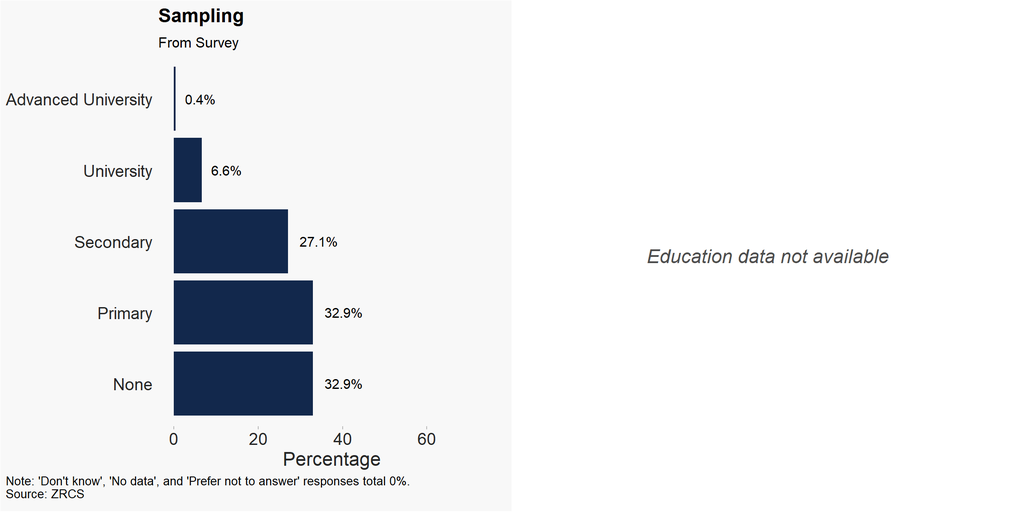

## Employment

The available data on unemployment in Zambia presents some contradictions. According to World Bank database, the labor force participation rate in 2016 was reported to be 75%. However, data from the Zambian Ministry of Labour and Social Security for 2020 indicates a lower rate of 35% for the labor force.

To establish an approximation, we utilized the average employment-to-population ratio of 20.2% based on the Ministry’s data for the Eastern and Southern provinces. It is worth noting that the working age population in these two provinces is nearly identical. Additionally, it is important to consider that the working age population encompasses individuals aged 15 and above, while our sample only includes individuals aged 18 and above.

Comparing our findings to the World Bank data, it appears that the people interviewed in our sample have a significantly higher unemployment rate than the national average. In 2016, the country’s unemployment rate was reported to be 7.8%, and the labor force participation rate was 75% according to the World Bank’s data (https://databank.worldbank.org/source/jobs/Type/TABLE/preview/on).

Nevertheless, it is worth noting that the Ministry of Labour and Social Security data aligns more closely with the percentage of employed individuals in our sample, which we then used in our analysis.

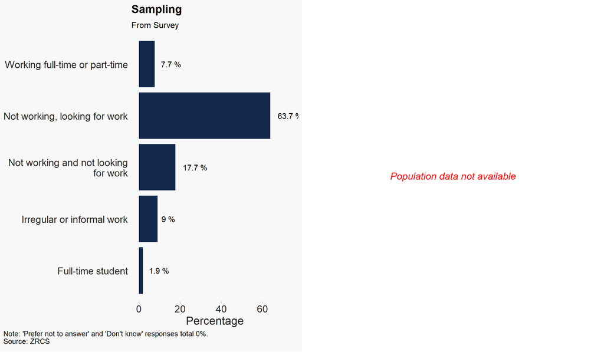

## Limitations

The data presented in this study should be interpreted with caution due to inherent methodological biases introduced by the sampling methods and the over-representation of specific groups, namely beneficiaries, volunteers, and donors. The use of purposive sampling, while effective for targeting particular insights, may not provide a fully representative picture of the broader community’s perceptions of the Zambian Red Cross Society (ZRCS).

The over-representation of beneficiaries, volunteers, and donors in the sample means that the findings predominantly reflect the views and experiences of these groups. Consequently, the results are more indicative of internal trust dynamics within the organization, particularly among those directly engaged with ZRCS, rather than the trust perceptions of the wider community. This caveat necessitates that the analysis and conclusions drawn from this data be used primarily for internal purposes, specifically to understand and enhance trust among beneficiaries and volunteers of the Red Cross.

To mitigate some of the biases associated with the sampling method, post-stratification techniques were applied based on age, location, and employment status (employed and unemployed). These adjustments aim to balance the sample and provide a more nuanced understanding of the data. However, users of this data should remain mindful of these limitations and avoid generalizing the findings to the broader community without further validation.

# Survey Results

The charts below present the survey answers as percentages, offering visualization of the Community Trust levels by subdimensions. They illustrate the distribution of community’s perceptions of the competencies and values.

## Perception of trust

### Competencies

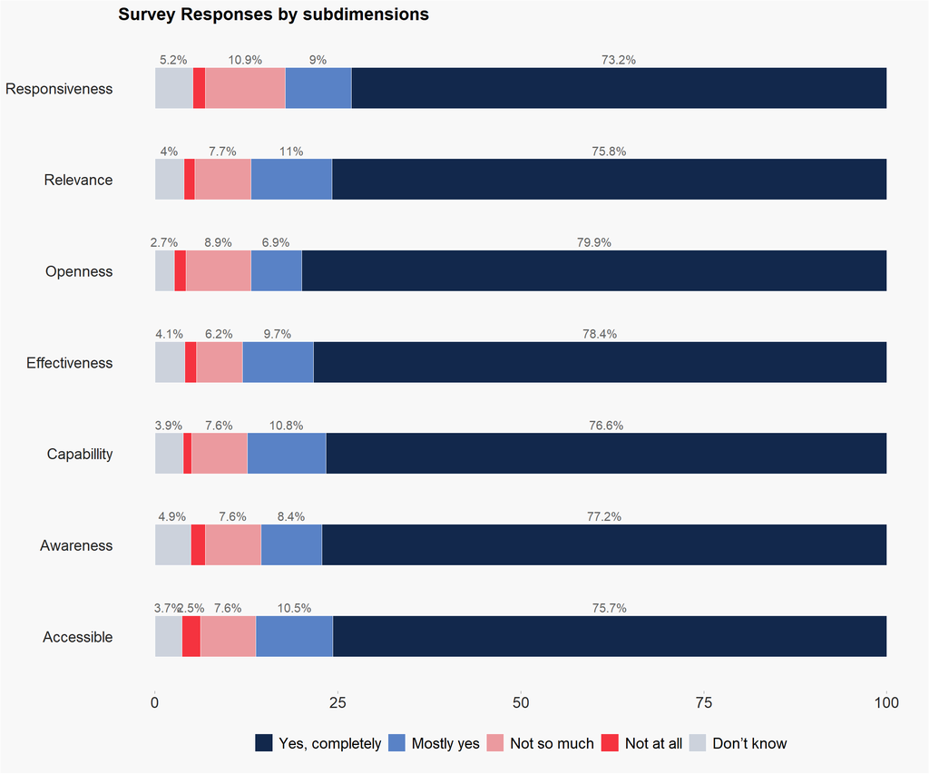

### Values

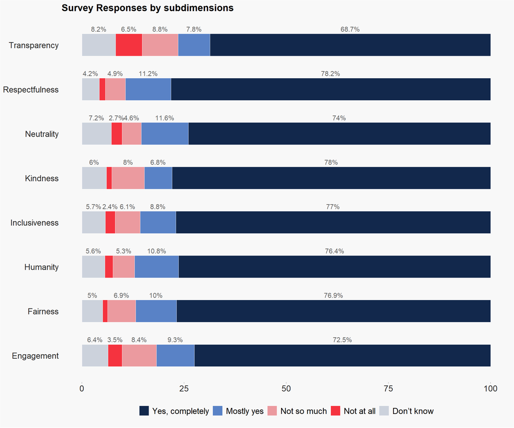

## Contextual questions

This section presents findings on community members’ experiences with and behaviors toward the Red Cross. These questions explore interactions, perceptions, and engagement patterns, offering insights into how the Red Cross is viewed and utilized within the community.

### Experiences

The chart illustrates community engagement with the Zambian Red Cross Society, showing that 72.8% have volunteered, 77.2% have requested support, 64% have received aid, and 67.1% have made donations. This reflects the context of the study where ZRCS conducted the Community Trust Index in the program’s implementation area.

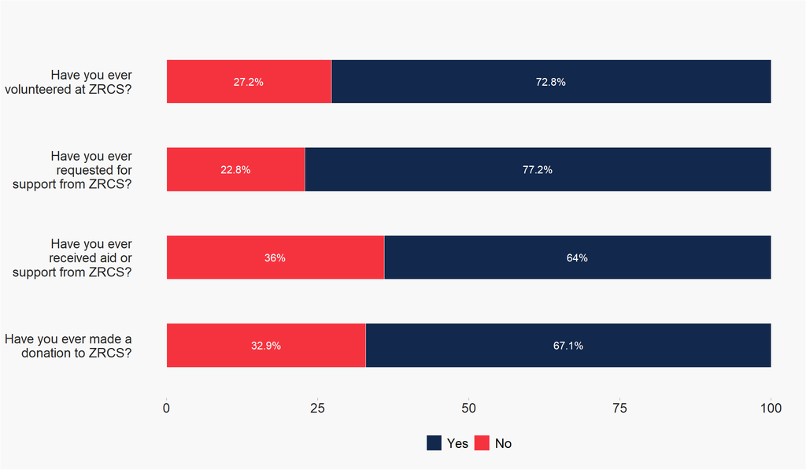

### Behaviours

Survey data indicates behaviours regarding the Zambian Red Cross Society (ZRCS), showing that 85% have recommended ZRCS to people needing support, 76.4% have provided feedback, 87.5% have followed advice during a crisis, and 87.3% have shared ZRCS information with others.

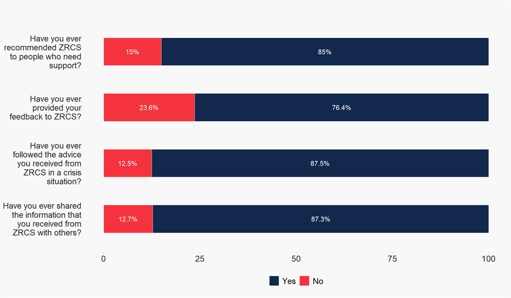

### Intention

The data shows strong community trust in ZRCS, with high likelihoods of sharing information, seeking support, volunteering, recommending, providing feedback, donating, and following crisis advice.

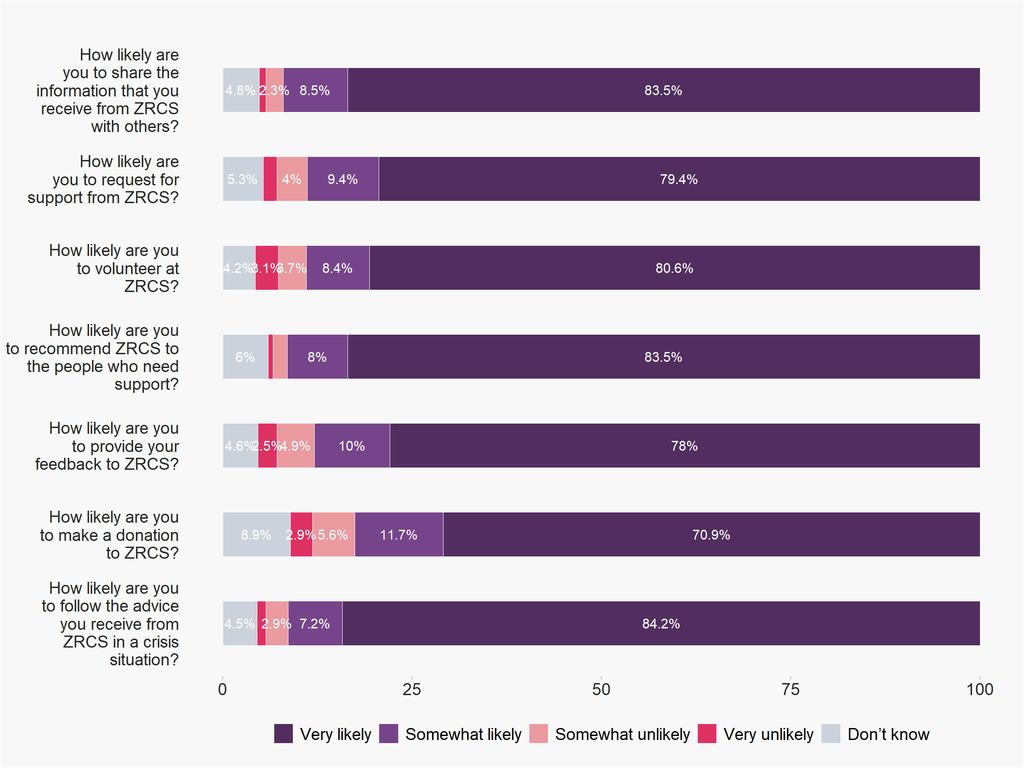

# Score

This score is derived from responses to questions that assess perceptions of competencies and values, providing a comprehensive measure of trust. A higher score indicates stronger trust, suggesting that community members believe their needs are being addressed and their values are respected. *Learn more about scoring method: Methods*

## Overall Score

For values, “Respectfulness” scores the highest at 8.94, reflecting strong positive perceptions in this area. “Transparency” is the lowest-scoring value at 8.04, indicating a potential area for enhancement. Other values like “Fairness” (8.81) and “Kindness” (8.73) are also rated highly.

Overall, the data suggests that while there are strong perceptions of effectiveness, respectfulness, and fairness, there is room for improvement in responsiveness and transparency.

*Learn more about weighting process: Weighting*

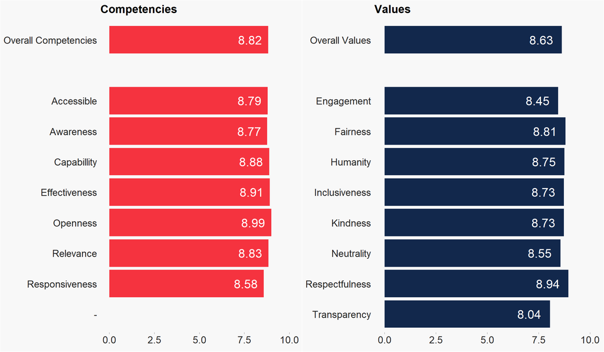

## Score by factors

The chart illustrates perceived competencies and values across various demographics, including gender, birthplace, education level, province, district, and experiences with the Zambian Red Cross Society (ZRCS) such as being a beneficiary, requesting support, donating, volunteering, and providing feedback. It evaluates how different groups rate attributes like effectiveness and engagement, providing insights into strengths and areas for improvement. This helps stakeholders tailor their approaches to diverse population needs.

*Distribution of mean scores for values and competencies per demographic questions*

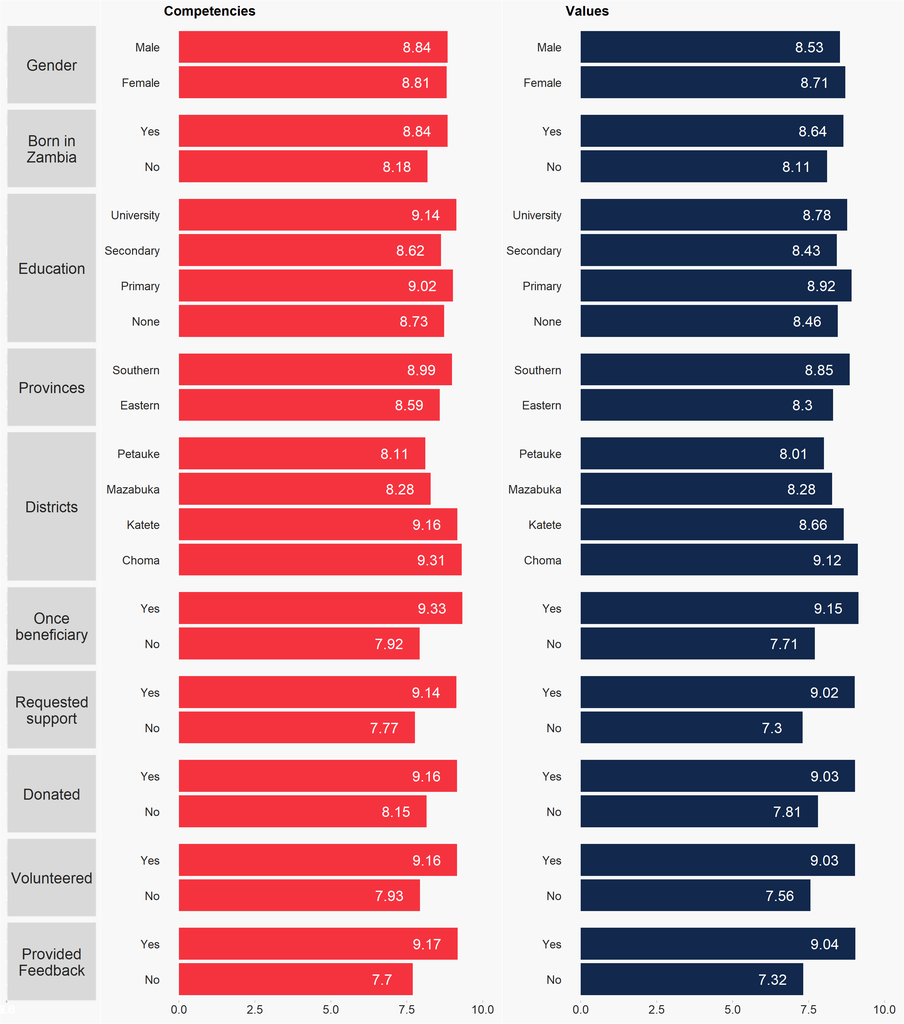

## Score by respondent profile

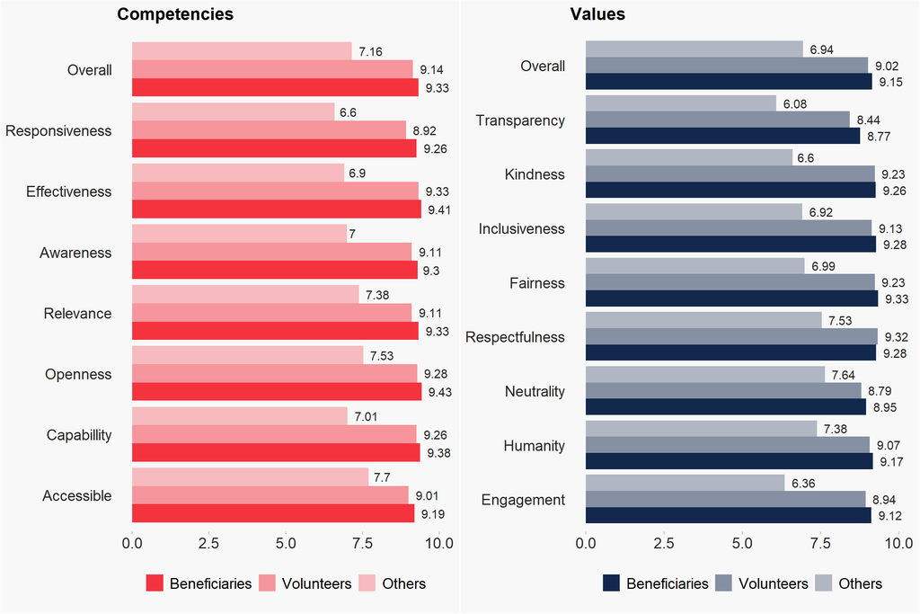

# Methods and Metrics

## Metrics

### Gender

Respondents by Gender

| Gender | Total Respondents | Percentage (%) |
| --- | --- | --- |
| Female | 418 | 55.5 |
| Male | 335 | 44.5 |
| Other or did not answer | 0 | 0.0 |
| Total | 753 | 100.0 |

### Age

Respondents by Age Group

| Age Group | Total Respondents | Percentage (%) |
| --- | --- | --- |
| 18 to 29 | 267 | 35.5 |
| 30 to 39 | 214 | 28.4 |
| 40 to 49 | 129 | 17.1 |
| 50 to 59 | 92 | 12.2 |
| 60 and older | 51 | 6.8 |

### Geographic

Respondents by District and Region

| Region | District | Total Respondents | Percentage (%) |
| --- | --- | --- | --- |
| Eastern | Petauke | 167 | 54.6 |
| Eastern | Katete | 139 | 45.4 |
| Eastern | TOTAL | 306 | 100.0 |
| Southern | Choma | 306 | 68.5 |
| Southern | Mazabuka | 141 | 31.5 |
| Southern | TOTAL | 447 | 100.0 |

### Relationship with RC

Respondents by relationship with RC

| Profile | Total Respondents |
| --- | --- |
| Aid recipient | 482 |
| Volunteer | 548 |
| Other | 121 |

## Methods

**Scoring methodology**

To determine the score, we employ the following method:

1. Survey Structure The CTI survey includes multiple questions grouped under sub-dimensions of two main categories:
   - Competencies (e.g., reliability, effectiveness, technical proficiency)
   - Values (e.g., ethics, integrity, fairness, transparency)
2. Sub-Dimension Scoring

   Each sub-dimension comprises several survey items (questions).Respondents answer on a Likert-type scale (1 to 4 - Don’t not is excluded). For each sub-dimension:

   *Sub-dimension Score = ∑ (Weighted Response Scores) / Number of Items*

If weights are not empirically derived, equal weighting is typically applied to each item.

3. Dimension Scoring

Once all sub-dimension scores are calculated, the Competency Score and Values Score are each derived as the arithmetic mean of their respective sub-dimension scores:

- *Competency Score = ∑(Sub-dimension Scores for Competency) /𝑛*
- *Values Score = ∑(Sub-dimension Scores for Values)/𝑚*

where 𝑛 and 𝑚 are the number of sub-dimensions in each category.

4. Overall Scoring

   The final Community Trust Index score is the arithmetic mean of the Competency and Values scores:
- *CTI Score = (Competency Score + Values Score)/2*

## Weighting

**Weighting vs. unweighting**

The weighted results show slightly smaller means, with minimal differences from unweighted data, except for the openness question, which shows a slightly larger decrease in the overall mean value.

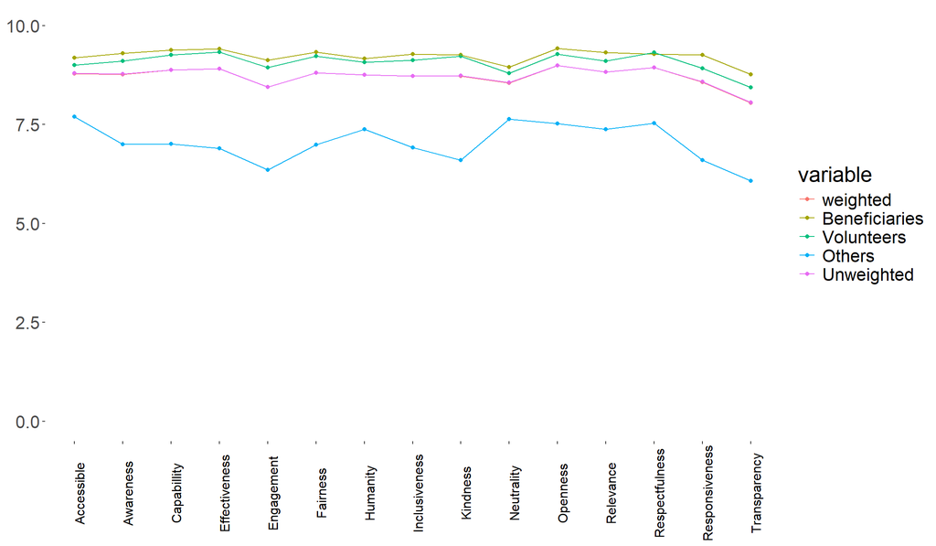

## Drivers Correlation

**Correlation matrix**

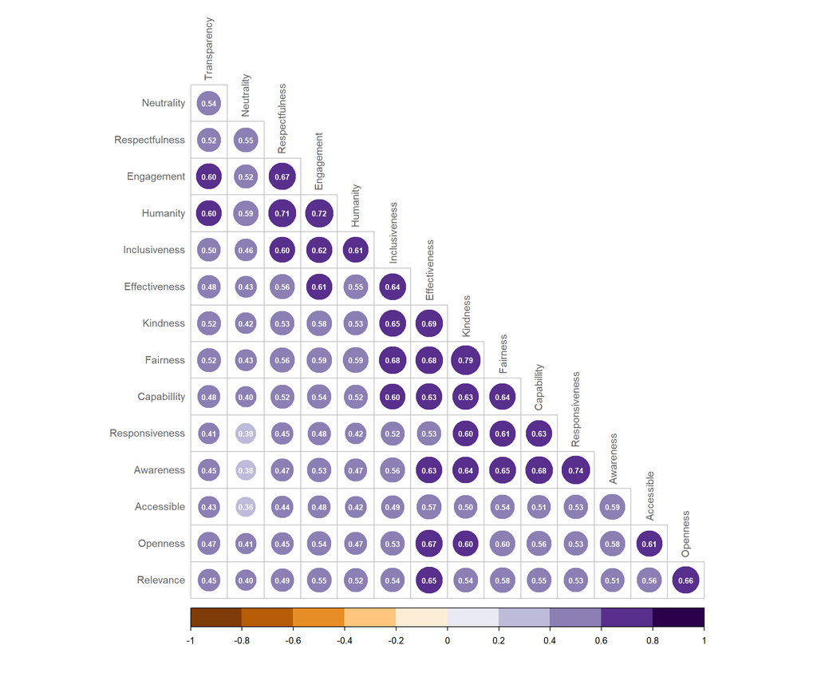

## Significance testing

**Significance testing**

| Dimension | Drivers | Volunteer-Other | Volunteer-Beneficiary | Benficiary-Other |
| --- | --- | --- | --- | --- |
| Competency | Capabillity | Yes | No | Yes |
| Competency | Responsiveness | Yes | Yes | Yes |
| Competency | Awareness | Yes | No | Yes |
| Competency | Accessible | Yes | No | Yes |
| Competency | Openness | Yes | No | Yes |
| Competency | Relevance | Yes | No | Yes |
| Competency | Effectiveness | Yes | No | Yes |
| Value | Kindness | Yes | No | Yes |
| Value | Fairness | Yes | No | Yes |
| Value | Inclusiveness | Yes | No | Yes |
| Value | Respectfulness | Yes | No | Yes |
| Value | Engagement | Yes | No | Yes |
| Value | Humanity | Yes | No | Yes |
| Value | Transparency | Yes | No | Yes |
| Value | Neutrality | Yes | No | Yes |

# Download

Download Summary Excel File